# IODS course project

Kalle Karvonen

# Introduction to Open Data Science - Course Project

# About the project

**Happy** *to be in the course and am looking forward to learning about how to link my stuff to github as I already have some knowledge learning from machine learning courses and multiomics* *I did not really go too deep into the course book as I have previous experience with R, but it is good that there is a more up to date book for the course although I believe that lot of coding is learned through just googling the problems and more recently by including ai into syntax troubleshooting*

[*https://kalkarvonen.github.io/IODS-project/*](https://kalkarvonen.github.io/IODS-project/)

```r
# This is a so-called "R chunk" where you can write R code.
#
date()
```

```
## [1] "Tue Dec 12 01:20:50 2023"
```

# Regression and model validation

- First we read in the dataset

```r
students2014 <- read.csv("C:/Users/Kalka/OneDrive/Desktop/Random/School/Open_Data/IODS-project/learning2014.csv")
## This dataset consists of information from 166 people on 7 different parameters including their gender,age, and certain learning questionnaire parameters. The point of the questionnaire was to see how the students course results correlate with their learning approaches and attitude towards a certain statistics course. Deep stra and surf correlate to study skill dimensions
students2014
```

```
##     gender Age attitude     deep  stra     surf Points
## 1        F  53      3.7 3.583333 3.375 2.583333     25
## 2        M  55      3.1 2.916667 2.750 3.166667     12
## 3        F  49      2.5 3.500000 3.625 2.250000     24
## 4        M  53      3.5 3.500000 3.125 2.250000     10
## 5        M  49      3.7 3.666667 3.625 2.833333     22
## 6        F  38      3.8 4.750000 3.625 2.416667     21
## 7        M  50      3.5 3.833333 2.250 1.916667     21
## 8        F  37      2.9 3.250000 4.000 2.833333     31
## 9        M  37      3.8 4.333333 4.250 2.166667     24
## 10       F  42      2.1 4.000000 3.500 3.000000     26
## 11       M  37      3.9 3.583333 3.625 2.666667     31
## 12       F  34      3.8 3.833333 4.750 2.416667     31
## 13       F  34      2.4 4.250000 3.625 2.250000     23
## 14       F  34      3.0 3.333333 3.500 2.750000     25
```

[output cut: 152 more lines]

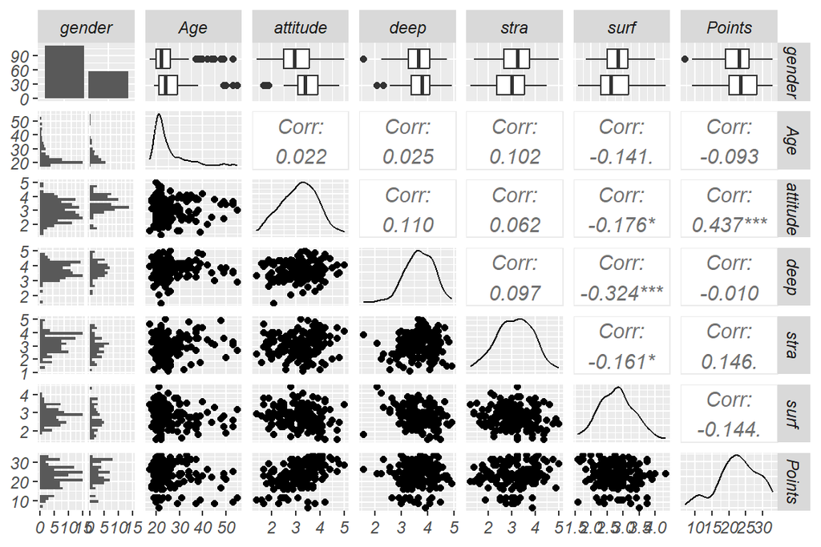

```r
# graphical overview of the data can be shown by using ggpairs
library(GGally)
library(ggplot2)
# create an plot matrix with ggpairs()
ggpairs(students2014, lower = list(combo = wrap("facethist", bins = 20)))
```

```r
# create a regression model with multiple explanatory variables
my_model2 <- lm(Points ~ attitude + stra+surf+deep+Age+gender, data = students2014)

# print out a summary of the model
summary(my_model2)
```

```
##
## Call:
## lm(formula = Points ~ attitude + stra + surf + deep + Age + gender,
##     data = students2014)
##
## Residuals:
##      Min       1Q   Median       3Q      Max
## -17.4506  -3.2479   0.3879   3.5243  11.4820
##
## Coefficients:
##             Estimate Std. Error t value Pr(>|t|)
## (Intercept) 18.30246    5.25723   3.481 0.000644 ***
## attitude     3.44300    0.59776   5.760 4.24e-08 ***
## stra         0.95871    0.55150   1.738 0.084083 .
## surf        -1.10891    0.84467  -1.313 0.191132
## deep        -1.04279    0.78438  -1.329 0.185606
## Age         -0.09607    0.05396  -1.780 0.076929 .
## genderM     -0.05858    0.92985  -0.063 0.949845
## ---
## Signif. codes:  0 '***' 0.001 '**' 0.01 '*' 0.05 '.' 0.1 ' ' 1
##
## Residual standard error: 5.265 on 159 degrees of freedom
## Multiple R-squared:  0.2312, Adjusted R-squared:  0.2021
## F-statistic: 7.967 on 6 and 159 DF,  p-value: 1.599e-07
```

- in this overview you can see the different correlations between points that the student got and the answers they gave. From this we can say that a positive attitude towards statistics correlated positively with points gained from the course. The other factors did not correlate with statistical significance towards the points
- Below is a summary of how this data shows the correlation of attitude age and strategical methods towards a course and the results on a linear regression model. The only one that correlates stronly is once again the attitude, However stra and age also seem to have some correlation but not statistically significant.

```r
library(ggplot2)

# fit a linear model
my_model <- lm(Points ~ attitude+Age+stra, data = students2014)

# print out a summary of the model
summary(my_model)
```

```
##
## Call:
## lm(formula = Points ~ attitude + Age + stra, data = students2014)
##
## Residuals:
##      Min       1Q   Median       3Q      Max
## -18.1149  -3.2003   0.3303   3.4129  10.7599
##
## Coefficients:
##             Estimate Std. Error t value Pr(>|t|)
## (Intercept) 10.89543    2.64834   4.114 6.17e-05 ***
## attitude     3.48077    0.56220   6.191 4.72e-09 ***
## Age         -0.08822    0.05302  -1.664   0.0981 .
## stra         1.00371    0.53434   1.878   0.0621 .
## ---
## Signif. codes:  0 '***' 0.001 '**' 0.01 '*' 0.05 '.' 0.1 ' ' 1
##
## Residual standard error: 5.26 on 162 degrees of freedom
## Multiple R-squared:  0.2182, Adjusted R-squared:  0.2037
## F-statistic: 15.07 on 3 and 162 DF,  p-value: 1.07e-08
```

-Here we run the fitting again removing the variables that had no statistical significances shown by the *** marking and only run it by explaining points with attitude towards the course and we also plot the two variables that show correlation

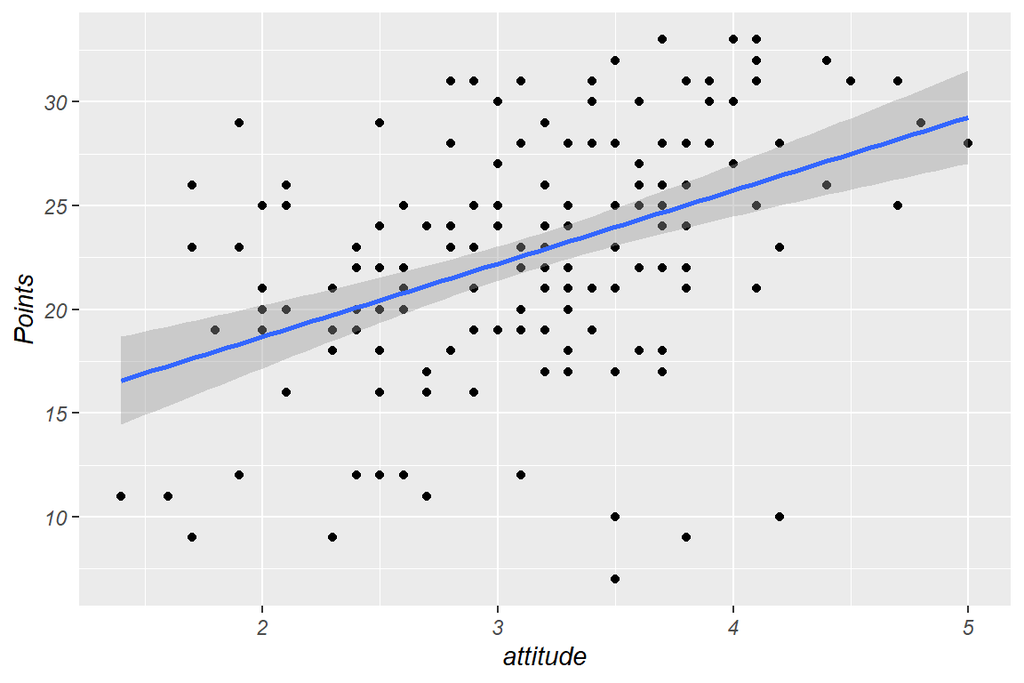

```r
qplot(attitude, Points, data = students2014) + geom_smooth(method = "lm")
```

```r
# fit a linear model
my_model <- lm(Points ~ attitude, data = students2014)

# print out a summary of the model
summary(my_model)
```

```
##
## Call:
## lm(formula = Points ~ attitude, data = students2014)
##
## Residuals:
##      Min       1Q   Median       3Q      Max
## -16.9763  -3.2119   0.4339   4.1534  10.6645
##
## Coefficients:
##             Estimate Std. Error t value Pr(>|t|)
## (Intercept)  11.6372     1.8303   6.358 1.95e-09 ***
## attitude      3.5255     0.5674   6.214 4.12e-09 ***
## ---
## Signif. codes:  0 '***' 0.001 '**' 0.01 '*' 0.05 '.' 0.1 ' ' 1
##
## Residual standard error: 5.32 on 164 degrees of freedom
## Multiple R-squared:  0.1906, Adjusted R-squared:  0.1856
## F-statistic: 38.61 on 1 and 164 DF,  p-value: 4.119e-09
```

- As you see in the summary of a linear model for this data for every scaled point of attitude our expected points increase by 3.52

– note however that the R squared value is only 0.19 which means that our model only accounts for 19% of the variability in the data and thus might not be an accurate method to model this data –> in other words points are only 19% explained by course attitude

- Lastly we produce some diagnostic plots as in ex2

```r
# create a regression model with multiple explanatory variables
my_model2 <- lm(Points ~ attitude, data = students2014)

# draw diagnostic plots using the plot() function. Choose the plots 1, 2 and 5
my_model2
```

```
##
## Call:
## lm(formula = Points ~ attitude, data = students2014)
##
## Coefficients:
## (Intercept)     attitude
##      11.637        3.525
```

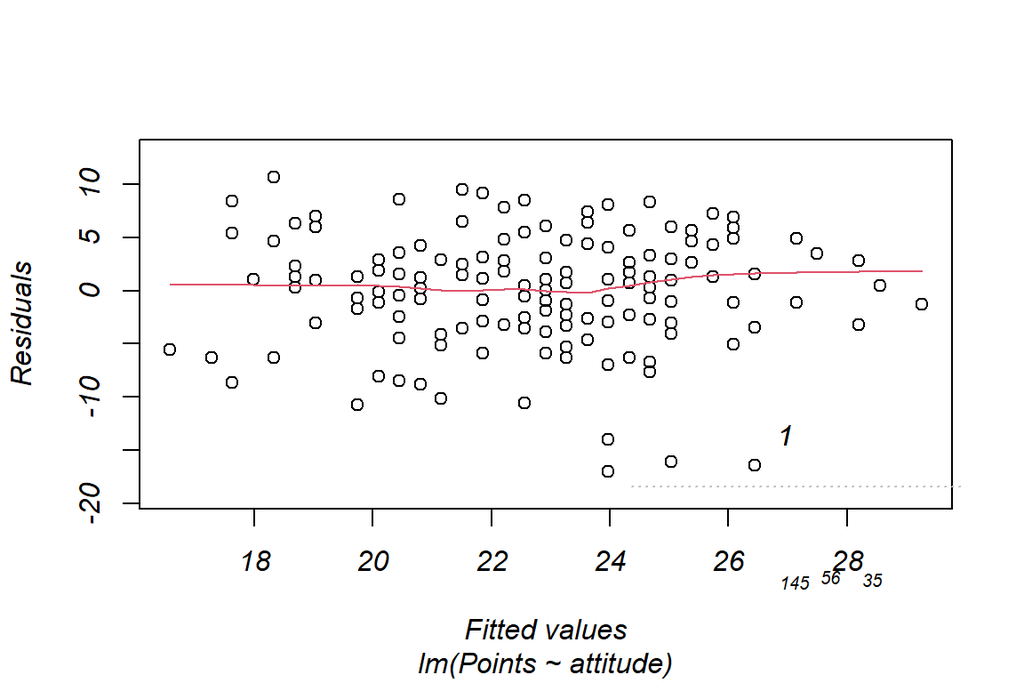

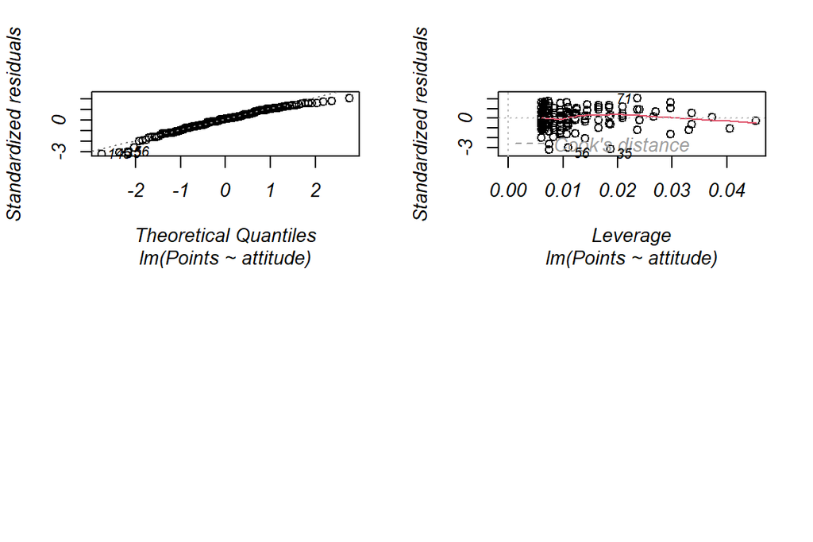

```r
plot(my_model2,which = c(1,2,5),par(mfrow=c(2,2)))
```

- Based on the course book fig 3.4a the Residuals against Fitted values plot shows that our fitted model should be of appropriate quality as there is no clear curvature in our values which would indicate that the model would need transformation.
- for the standardized residuals we see some potential outliers on the left side which may be the reason why our R-squared is so low. Perhaps there are people who get low scores despite having a good attitude score which lower the predictability ?

```r
date()
```

```
## [1] "Tue Dec 12 01:20:56 2023"
```

Here we go again…

# Logistic Regression

```r
#using the file I made in data wrangling
getwd()
```

```
## [1] "C:/Users/Kalka/OneDrive/Desktop/Random/School/Open_Data/IODS-project"
```

```r
alc <- read.csv("alc.csv")
colnames(alc)
```

```
##  [1] "school"     "sex"        "age"        "address"    "famsize"
##  [6] "Pstatus"    "Medu"       "Fedu"       "Mjob"       "Fjob"
## [11] "reason"     "guardian"   "traveltime" "studytime"  "schoolsup"
## [16] "famsup"     "activities" "nursery"    "higher"     "internet"
## [21] "romantic"   "famrel"     "freetime"   "goout"      "Dalc"
## [26] "Walc"       "health"     "paid"       "failures"   "absences"
## [31] "G1"         "G2"         "G3"         "alc_use"    "high_use"
```

- This dataset consists of the variables shown above taken from students of a math and portuguese class and their performance. Data also has alcohol consumption added to it
- Daily alcohol consumption Dalc and Weekend alkohol consumption Walc from which alc_use is calculated by taking the average of the two. high_use is True if over the average is over 2 and False if under 2
- We will use this data to study the relationship between alcohol consumption and other variables in the data

For example if we expect men to be more likely to consume high amounts of alcohol and we want to use this data to test if there is a difference between alcohol consumption (high or low between the genders) we could do it like this

```r
# access the tidyverse packages dplyr and ggplot2
library(dplyr); library(ggplot2)
# First summarize the data a bit to see what to expect
alc %>% group_by(sex,high_use) %>% summarise(count = n())
```

[output not shown]

```
## # A tibble: 4 × 3
## # Groups:   sex [2]
##   sex   high_use count
##   <chr> <lgl>    <int>
## 1 F     FALSE      154
## 2 F     TRUE        41
## 3 M     FALSE      105
## 4 M     TRUE        70
```

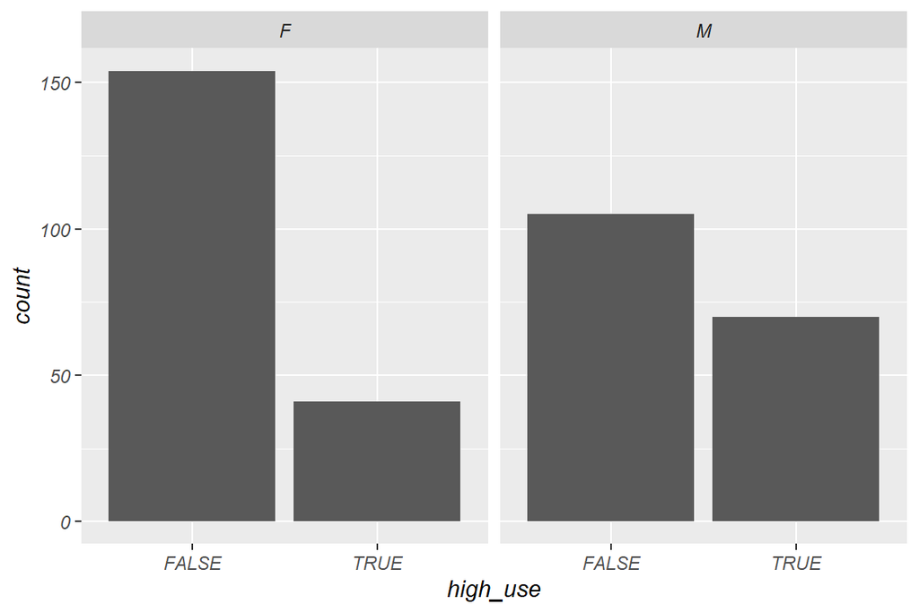

```r
#Based on this we could already see that there will be a difference

# Plot the differences
g1 <- ggplot(data = alc, aes(x=high_use))
# draw a bar plot of high_use by sex
g1+geom_bar()+facet_wrap("sex")
```

-Based on this we could say that more men consume high amounts of alcohol when compared to women”

-similarily here is a different type of plot for alcohol usage (high or low) and age - it is expected that alcohol consumption should be low for underage people and that we get more high alcohol use people with higher ages

```r
alc %>% group_by(high_use,age) %>% summarise(count = n())
```

```
## # A tibble: 12 × 3
## # Groups:   high_use [2]
##    high_use   age count
##    <lgl>    <int> <int>
##  1 FALSE       15    63
##  2 FALSE       16    74
##  3 FALSE       17    62
##  4 FALSE       18    52
##  5 FALSE       19     7
##  6 FALSE       20     1
##  7 TRUE        15    18
##  8 TRUE        16    28
##  9 TRUE        17    35
## 10 TRUE        18    25
## 11 TRUE        19     4
## 12 TRUE        22     1
```

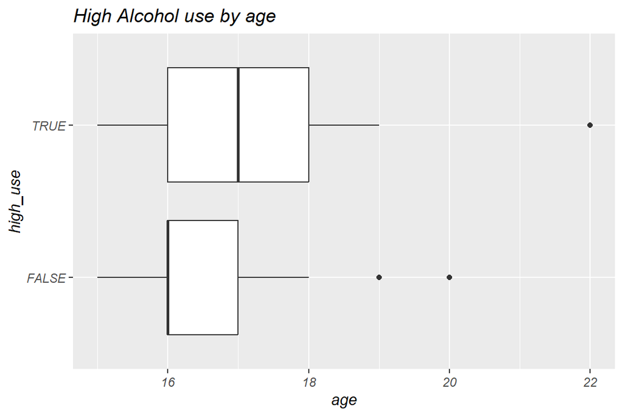

```r
# initialize a plot of high_use and age
g2 <- ggplot(alc,aes(x=age,y=high_use))
g2+geom_boxplot()+ggtitle("High Alcohol use by age")
```

```r
# define the plot as a box plot and draw it
```

```r
# find the model with glm()
m <- glm(high_use ~ sex, data = alc, family = "binomial")
n <- glm(high_use~age,data=alc,family="binomial")

# print out a summary of the model
summary(m)
```

```
##
## Call:
## glm(formula = high_use ~ sex, family = "binomial", data = alc)
##
## Coefficients:
##             Estimate Std. Error z value Pr(>|z|)
## (Intercept)  -1.3234     0.1757  -7.530 5.06e-14 ***
## sexM          0.9179     0.2339   3.925 8.67e-05 ***
## ---
## Signif. codes:  0 '***' 0.001 '**' 0.01 '*' 0.05 '.' 0.1 ' ' 1
##
## (Dispersion parameter for binomial family taken to be 1)
##
##     Null deviance: 452.04  on 369  degrees of freedom
## Residual deviance: 436.13  on 368  degrees of freedom
## AIC: 440.13
##
## Number of Fisher Scoring iterations: 4
```

```r
summary(n)
```

```
##
## Call:
## glm(formula = high_use ~ age, family = "binomial", data = alc)
##
## Coefficients:
##             Estimate Std. Error z value Pr(>|z|)
## (Intercept) -4.07538    1.60980  -2.532   0.0114 *
## age          0.19414    0.09628   2.016   0.0438 *
## ---
## Signif. codes:  0 '***' 0.001 '**' 0.01 '*' 0.05 '.' 0.1 ' ' 1
##
## (Dispersion parameter for binomial family taken to be 1)
##
##     Null deviance: 452.04  on 369  degrees of freedom
## Residual deviance: 447.94  on 368  degrees of freedom
## AIC: 451.94
##
## Number of Fisher Scoring iterations: 4
```

```r
# print out the coefficients of the model
coef(m)
```

```
## (Intercept)        sexM
##  -1.3233805   0.9179154
```

```r
coef(n)
```

```
## (Intercept)         age
##  -4.0753783   0.1941355
```

- as you can see above both sex and age seem to have some capability of predicting high alcohol use. Note that in the sex part the model only shows the Males because of how R handles categorical variables by performing dummy coding. In this case the sexF has been used as a reference class for sexM

all the p values in both tests (age and sex) show that there is a statistical significance although age does not seem to be so strong predictor of high alcohol use as sex and it is probably not a very good predictor to use.

- How about odds ratio and its confidence interval.

```r
# compute odds ratios (OR)
ORm <- coef(m) %>% exp

# compute confidence intervals (CI)
CIm <- confint(m)
# print out the odds ratios with their confidence intervals
cbind(ORm, CIm)
```

```
##                   ORm      2.5 %     97.5 %
## (Intercept) 0.2662338 -1.6802691 -0.9894944
## sexM        2.5040650  0.4639196  1.3822585
```

```r
ORn <- coef(n) %>% exp
CIn <- confint(n)
cbind(ORn,CIn)
```

```
##                    ORn        2.5 %     97.5 %
## (Intercept) 0.01698579 -7.271045604 -0.9407959
## age         1.21426075  0.006116096  0.3847577
```

- similarily to above here we also see some correlation between age and high alcohol consumption but this time only 1.2 times as high. Because we are talking of continuous variable such as age every increase in age should raise the odds of being a high alcohol user by 1.2. When we think about it this is not feasible since alcohol consumption does not grow exponentially as we age. so Age might not be a good model even though in this case it is statistically significant. Also to note is that this cohort was partly underage and they cannot legally buy alcohol so data might not be reliable in that sense.
- Testing the predictitive power of these modesl

```r
probabilities_m <- predict(m, type = "response")
probabilities_n <- predict(n,type = "response")
alc <- mutate(alc, probability_sex = probabilities_m)
alc <- mutate(alc, probability_age = probabilities_n)
#now we have the predictions here and we can use them to predict a treshold of for example 0.5
alc <- mutate(alc, predicted_high_use_sex = ifelse(probability_sex > 0.5, TRUE, FALSE))
alc <- mutate(alc, predicted_high_use_age = ifelse(probability_age > 0.5, TRUE, FALSE))

# Now we can print these into their own 2x2 crosstables to see how they worked
Alcohol_Sex <- table(High_Use=alc$high_use, Prediction=alc$predicted_high_use_sex)
print(Alcohol_Sex)
```

```
##         Prediction
## High_Use FALSE
##    FALSE   259
##    TRUE    111
```

```r
Alcohol_Age <- table(High_Use=alc$high_use, Prediction=alc$predicted_high_use_age)
print(Alcohol_Age)
```

```
##         Prediction
## High_Use FALSE TRUE
##    FALSE   259    0
##    TRUE    110    1
```

```r
date()
```

```
## [1] "Tue Dec 12 01:20:57 2023"
```

# Clustering and Classification

- Loading in the Boston dataset, which contains the housing values in suburbs of Boston in 506 rows of data and 14 different columns of variables such as crime rate median value,age and proportion of blacks by town.

```r
library(MASS)
```

```r
library(ggplot2)

dim(Boston)
```

```
## [1] 506  14
```

```r
str(Boston)
```

```
## 'data.frame':    506 obs. of  14 variables:
##  $ crim   : num  0.00632 0.02731 0.02729 0.03237 0.06905 ...
##  $ zn     : num  18 0 0 0 0 0 12.5 12.5 12.5 12.5 ...
##  $ indus  : num  2.31 7.07 7.07 2.18 2.18 2.18 7.87 7.87 7.87 7.87 ...
##  $ chas   : int  0 0 0 0 0 0 0 0 0 0 ...
##  $ nox    : num  0.538 0.469 0.469 0.458 0.458 0.458 0.524 0.524 0.524 0.524 ...
##  $ rm     : num  6.58 6.42 7.18 7 7.15 ...
##  $ age    : num  65.2 78.9 61.1 45.8 54.2 58.7 66.6 96.1 100 85.9 ...
##  $ dis    : num  4.09 4.97 4.97 6.06 6.06 ...
##  $ rad    : int  1 2 2 3 3 3 5 5 5 5 ...
##  $ tax    : num  296 242 242 222 222 222 311 311 311 311 ...
##  $ ptratio: num  15.3 17.8 17.8 18.7 18.7 18.7 15.2 15.2 15.2 15.2 ...
##  $ black  : num  397 397 393 395 397 ...
##  $ lstat  : num  4.98 9.14 4.03 2.94 5.33 ...
##  $ medv   : num  24 21.6 34.7 33.4 36.2 28.7 22.9 27.1 16.5 18.9 ...
```

-Here we can summarize the variables on the data to see a bit how the values line up. We can also perform a pairwise analysis on the data to visualize it and the different variables effect on others. The data seems to have a high variability between datas and no clear distributions can be clearly seen by eye

```r
summary(Boston)
```

```
##       crim                zn             indus            chas
##  Min.   : 0.00632   Min.   :  0.00   Min.   : 0.46   Min.   :0.00000
##  1st Qu.: 0.08205   1st Qu.:  0.00   1st Qu.: 5.19   1st Qu.:0.00000
##  Median : 0.25651   Median :  0.00   Median : 9.69   Median :0.00000
##  Mean   : 3.61352   Mean   : 11.36   Mean   :11.14   Mean   :0.06917
##  3rd Qu.: 3.67708   3rd Qu.: 12.50   3rd Qu.:18.10   3rd Qu.:0.00000
##  Max.   :88.97620   Max.   :100.00   Max.   :27.74   Max.   :1.00000
##       nox               rm             age              dis
##  Min.   :0.3850   Min.   :3.561   Min.   :  2.90   Min.   : 1.130
##  1st Qu.:0.4490   1st Qu.:5.886   1st Qu.: 45.02   1st Qu.: 2.100
##  Median :0.5380   Median :6.208   Median : 77.50   Median : 3.207
##  Mean   :0.5547   Mean   :6.285   Mean   : 68.57   Mean   : 3.795
##  3rd Qu.:0.6240   3rd Qu.:6.623   3rd Qu.: 94.08   3rd Qu.: 5.188
##  Max.   :0.8710   Max.   :8.780   Max.   :100.00   Max.   :12.127
##       rad              tax           ptratio          black
##  Min.   : 1.000   Min.   :187.0   Min.   :12.60   Min.   :  0.32
##  1st Qu.: 4.000   1st Qu.:279.0   1st Qu.:17.40   1st Qu.:375.38
##  Median : 5.000   Median :330.0   Median :19.05   Median :391.44
##  Mean   : 9.549   Mean   :408.2   Mean   :18.46   Mean   :356.67
##  3rd Qu.:24.000   3rd Qu.:666.0   3rd Qu.:20.20   3rd Qu.:396.23
##  Max.   :24.000   Max.   :711.0   Max.   :22.00   Max.   :396.90
##      lstat            medv
##  Min.   : 1.73   Min.   : 5.00
##  1st Qu.: 6.95   1st Qu.:17.02
##  Median :11.36   Median :21.20
##  Mean   :12.65   Mean   :22.53
##  3rd Qu.:16.95   3rd Qu.:25.00
##  Max.   :37.97   Max.   :50.00
```

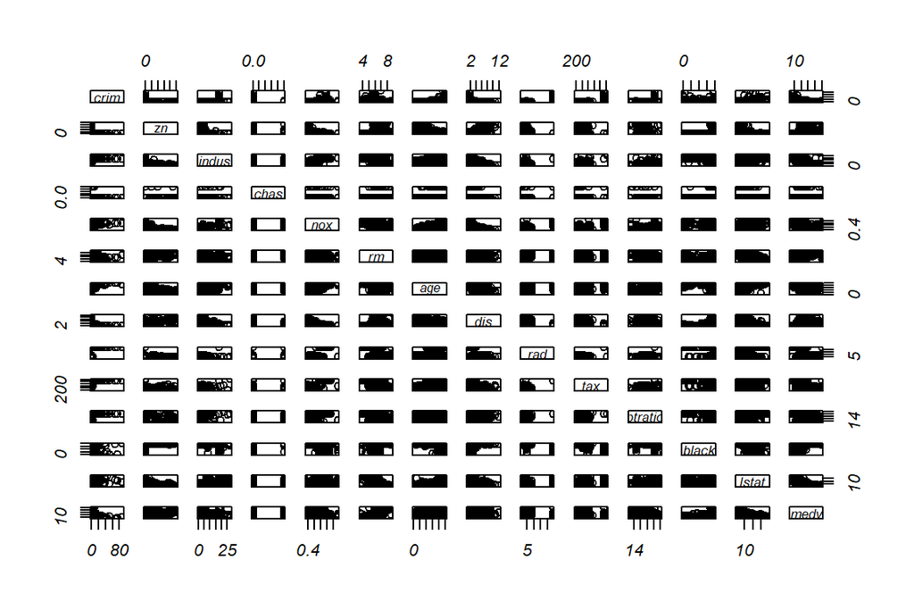

```r
pairs(Boston)
```

- This data above can be pretty hard to interpret due to it having so large amount of plots so we could for example do this to see how the plots look for three variables such as the amount of crime/capita, amount of blacks in the neighbourhood and the median property value.

-Based on this we could make some interpetations such as that the crime rate correlates negatively with the median value and that there seems to be no clear visual indication that the amount of blacks would correlate with the amount of crime or median value of owner occupied homes.

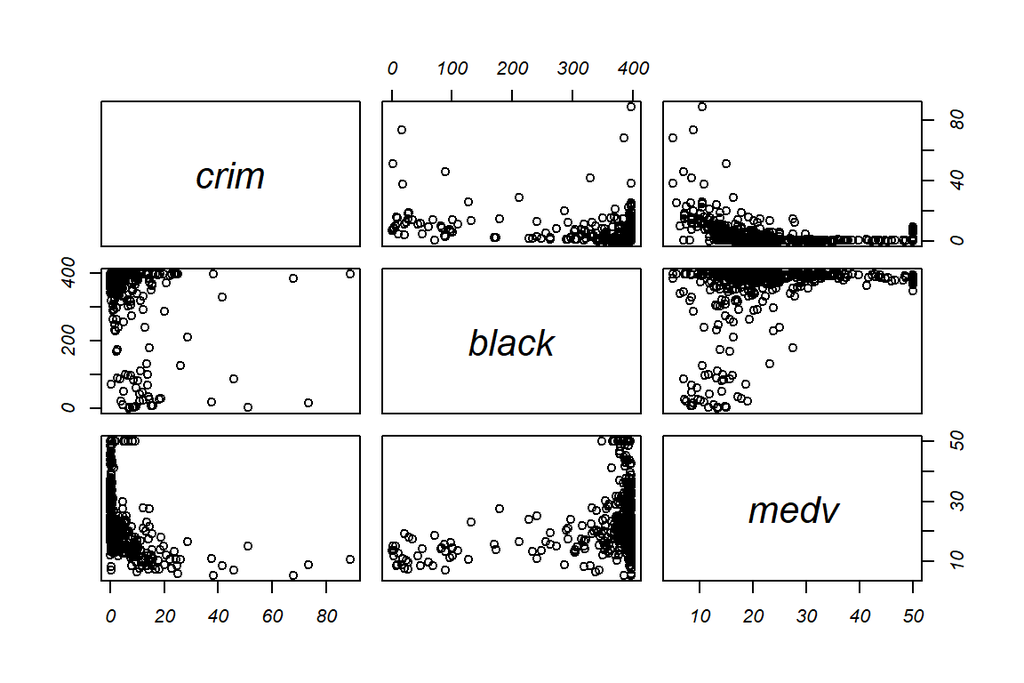

```r
pairs(Boston[,c(1,12,14)])
```

-Another good way to show any correlations on the data would be to use the correlation matrix which can be used to show correlation between variables

```r
# calculate the correlation matrix and round it
cor_matrix <- cor(Boston)

# print the correlation matrix
print(cor_matrix)
```

```
##                crim          zn       indus         chas         nox
## crim     1.00000000 -0.20046922  0.40658341 -0.055891582  0.42097171
## zn      -0.20046922  1.00000000 -0.53382819 -0.042696719 -0.51660371
## indus    0.40658341 -0.53382819  1.00000000  0.062938027  0.76365145
## chas    -0.05589158 -0.04269672  0.06293803  1.000000000  0.09120281
## nox      0.42097171 -0.51660371  0.76365145  0.091202807  1.00000000
## rm      -0.21924670  0.31199059 -0.39167585  0.091251225 -0.30218819
## age      0.35273425 -0.56953734  0.64477851  0.086517774  0.73147010
## dis     -0.37967009  0.66440822 -0.70802699 -0.099175780 -0.76923011
## rad      0.62550515 -0.31194783  0.59512927 -0.007368241  0.61144056
## tax      0.58276431 -0.31456332  0.72076018 -0.035586518  0.66802320
## ptratio  0.28994558 -0.39167855  0.38324756 -0.121515174  0.18893268
## black   -0.38506394  0.17552032 -0.35697654  0.048788485 -0.38005064
## lstat    0.45562148 -0.41299457  0.60379972 -0.053929298  0.59087892
## medv    -0.38830461  0.36044534 -0.48372516  0.175260177 -0.42732077
##                  rm         age         dis          rad         tax    ptratio
## crim    -0.21924670  0.35273425 -0.37967009  0.625505145  0.58276431  0.2899456
## zn       0.31199059 -0.56953734  0.66440822 -0.311947826 -0.31456332 -0.3916785
## indus   -0.39167585  0.64477851 -0.70802699  0.595129275  0.72076018  0.3832476
## chas     0.09125123  0.08651777 -0.09917578 -0.007368241 -0.03558652 -0.1215152
## nox     -0.30218819  0.73147010 -0.76923011  0.611440563  0.66802320  0.1889327
## rm       1.00000000 -0.24026493  0.20524621 -0.209846668 -0.29204783 -0.3555015
## age     -0.24026493  1.00000000 -0.74788054  0.456022452  0.50645559  0.2615150
## dis      0.20524621 -0.74788054  1.00000000 -0.494587930 -0.53443158 -0.2324705
## rad     -0.20984667  0.45602245 -0.49458793  1.000000000  0.91022819  0.4647412
## tax     -0.29204783  0.50645559 -0.53443158  0.910228189  1.00000000  0.4608530
## ptratio -0.35550149  0.26151501 -0.23247054  0.464741179  0.46085304  1.0000000
## black    0.12806864 -0.27353398  0.29151167 -0.444412816 -0.44180801 -0.1773833
## lstat   -0.61380827  0.60233853 -0.49699583  0.488676335  0.54399341  0.3740443
## medv     0.69535995 -0.37695457  0.24992873 -0.381626231 -0.46853593 -0.5077867
##               black      lstat       medv
## crim    -0.38506394  0.4556215 -0.3883046
## zn       0.17552032 -0.4129946  0.3604453
## indus   -0.35697654  0.6037997 -0.4837252
## chas     0.04878848 -0.0539293  0.1752602
## nox     -0.38005064  0.5908789 -0.4273208
## rm       0.12806864 -0.6138083  0.6953599
## age     -0.27353398  0.6023385 -0.3769546
## dis      0.29151167 -0.4969958  0.2499287
## rad     -0.44441282  0.4886763 -0.3816262
## tax     -0.44180801  0.5439934 -0.4685359
## ptratio -0.17738330  0.3740443 -0.5077867
## black    1.00000000 -0.3660869  0.3334608
## lstat   -0.36608690  1.0000000 -0.7376627
## medv     0.33346082 -0.7376627  1.0000000
```

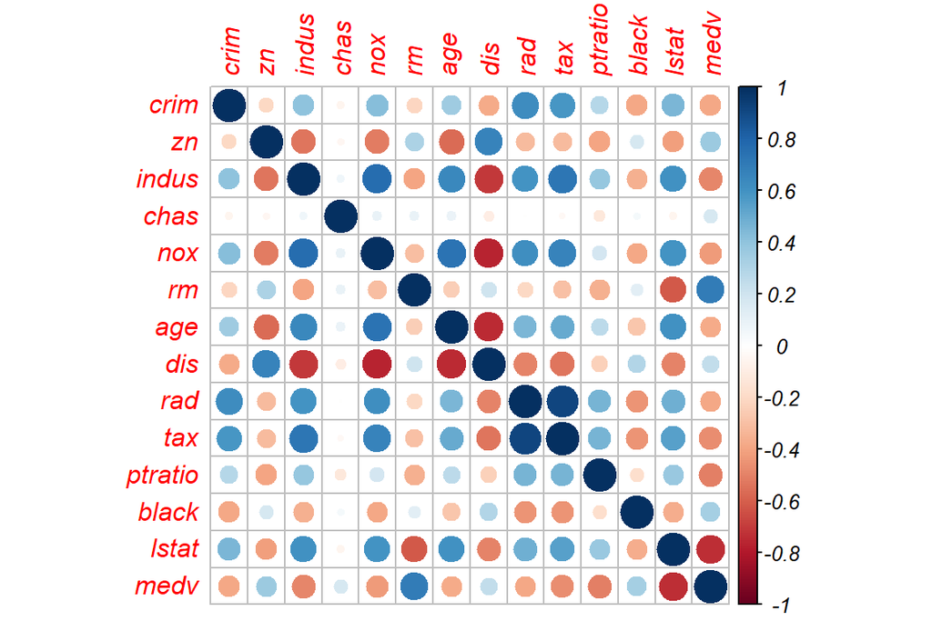

```r
# visualize the correlation matrix
library(corrplot)
corrplot(cor_matrix, method="circle")
```

- there are some variables that seem to correlate with each other.

- This dataset could use some scaling to make the distributions of the data a bit more readable. so lets perform scaling

```r
# center and standardize variables by using the mean as the center point
boston_scaled <- as.data.frame(scale(Boston))

# summaries of the variables
summary(Boston)
```

```
##       crim                zn             indus            chas
##  Min.   : 0.00632   Min.   :  0.00   Min.   : 0.46   Min.   :0.00000
##  1st Qu.: 0.08205   1st Qu.:  0.00   1st Qu.: 5.19   1st Qu.:0.00000
##  Median : 0.25651   Median :  0.00   Median : 9.69   Median :0.00000
##  Mean   : 3.61352   Mean   : 11.36   Mean   :11.14   Mean   :0.06917
##  3rd Qu.: 3.67708   3rd Qu.: 12.50   3rd Qu.:18.10   3rd Qu.:0.00000
##  Max.   :88.97620   Max.   :100.00   Max.   :27.74   Max.   :1.00000
##       nox               rm             age              dis
##  Min.   :0.3850   Min.   :3.561   Min.   :  2.90   Min.   : 1.130
##  1st Qu.:0.4490   1st Qu.:5.886   1st Qu.: 45.02   1st Qu.: 2.100
##  Median :0.5380   Median :6.208   Median : 77.50   Median : 3.207
##  Mean   :0.5547   Mean   :6.285   Mean   : 68.57   Mean   : 3.795
##  3rd Qu.:0.6240   3rd Qu.:6.623   3rd Qu.: 94.08   3rd Qu.: 5.188
##  Max.   :0.8710   Max.   :8.780   Max.   :100.00   Max.   :12.127
##       rad              tax           ptratio          black
##  Min.   : 1.000   Min.   :187.0   Min.   :12.60   Min.   :  0.32
##  1st Qu.: 4.000   1st Qu.:279.0   1st Qu.:17.40   1st Qu.:375.38
##  Median : 5.000   Median :330.0   Median :19.05   Median :391.44
##  Mean   : 9.549   Mean   :408.2   Mean   :18.46   Mean   :356.67
##  3rd Qu.:24.000   3rd Qu.:666.0   3rd Qu.:20.20   3rd Qu.:396.23
##  Max.   :24.000   Max.   :711.0   Max.   :22.00   Max.   :396.90
##      lstat            medv
##  Min.   : 1.73   Min.   : 5.00
##  1st Qu.: 6.95   1st Qu.:17.02
##  Median :11.36   Median :21.20
##  Mean   :12.65   Mean   :22.53
##  3rd Qu.:16.95   3rd Qu.:25.00
##  Max.   :37.97   Max.   :50.00
```

```r
summary(boston_scaled)
```

```
##       crim                 zn               indus              chas
##  Min.   :-0.419367   Min.   :-0.48724   Min.   :-1.5563   Min.   :-0.2723
##  1st Qu.:-0.410563   1st Qu.:-0.48724   1st Qu.:-0.8668   1st Qu.:-0.2723
##  Median :-0.390280   Median :-0.48724   Median :-0.2109   Median :-0.2723
##  Mean   : 0.000000   Mean   : 0.00000   Mean   : 0.0000   Mean   : 0.0000
##  3rd Qu.: 0.007389   3rd Qu.: 0.04872   3rd Qu.: 1.0150   3rd Qu.:-0.2723
##  Max.   : 9.924110   Max.   : 3.80047   Max.   : 2.4202   Max.   : 3.6648
##       nox                rm               age               dis
##  Min.   :-1.4644   Min.   :-3.8764   Min.   :-2.3331   Min.   :-1.2658
##  1st Qu.:-0.9121   1st Qu.:-0.5681   1st Qu.:-0.8366   1st Qu.:-0.8049
##  Median :-0.1441   Median :-0.1084   Median : 0.3171   Median :-0.2790
##  Mean   : 0.0000   Mean   : 0.0000   Mean   : 0.0000   Mean   : 0.0000
##  3rd Qu.: 0.5981   3rd Qu.: 0.4823   3rd Qu.: 0.9059   3rd Qu.: 0.6617
##  Max.   : 2.7296   Max.   : 3.5515   Max.   : 1.1164   Max.   : 3.9566
##       rad               tax             ptratio            black
##  Min.   :-0.9819   Min.   :-1.3127   Min.   :-2.7047   Min.   :-3.9033
##  1st Qu.:-0.6373   1st Qu.:-0.7668   1st Qu.:-0.4876   1st Qu.: 0.2049
##  Median :-0.5225   Median :-0.4642   Median : 0.2746   Median : 0.3808
##  Mean   : 0.0000   Mean   : 0.0000   Mean   : 0.0000   Mean   : 0.0000
##  3rd Qu.: 1.6596   3rd Qu.: 1.5294   3rd Qu.: 0.8058   3rd Qu.: 0.4332
##  Max.   : 1.6596   Max.   : 1.7964   Max.   : 1.6372   Max.   : 0.4406
##      lstat              medv
##  Min.   :-1.5296   Min.   :-1.9063
##  1st Qu.:-0.7986   1st Qu.:-0.5989
##  Median :-0.1811   Median :-0.1449
##  Mean   : 0.0000   Mean   : 0.0000
##  3rd Qu.: 0.6024   3rd Qu.: 0.2683
##  Max.   : 3.5453   Max.   : 2.9865
```

- now we see that the values are scaled so that all the dataframes show identical mean of zero meaning they have been centered around it.Basically this means we now have some negative values but overall we should have less outliers.

-Now we can add categorical variables to the crime rates of our scaled data by first doing quantiles of values and then labeling these quantiles.

```r
# c reating the quantile bins for our labeling
bins <- quantile(boston_scaled$crim)
bins
```

```
##           0%          25%          50%          75%         100%
## -0.419366929 -0.410563278 -0.390280295  0.007389247  9.924109610
```

```r
#creating a vector label which contains our desired labels
label <- c("low","med_low","med_high","high")
# create a categorical variable 'crime'
crime <- cut(boston_scaled$crim, breaks = bins, include.lowest = TRUE,labels = label)

# look at the table of the new factor crime
table(crime)
```

```
## crime
##      low  med_low med_high     high
##      127      126      126      127
```

```r
# now we have a uniform distribution of crime rate factors
# remove original crim from the dataset
boston_scaled <- dplyr::select(boston_scaled, -crim)

# add the new categorical value to scaled data
boston_scaled <- data.frame(boston_scaled, crime)
```

- Now we can use the created scaled data with categorical valuables to create training and test data for labeling purposes by dividing our dataset to 80% 20% split between training and test sets
- we also save the correct classes from our test data for quality control later on and remove the variable crime from the test data -So we use 80% of the data to train our model and 20% of data to do a test to see how accurate our model is.

```r
# number of rows in the Boston dataset
n <- nrow(boston_scaled)

# choose randomly 80% of the rows
ind <- sample(n,  size = n * 0.8)

# create train set
train <- boston_scaled[ind,]

# create test set
test <- boston_scaled[-ind,]

# save the correct classes from test data
correct_classes <- test$crime

# remove the crime variable from test data so that we can use our model to label it
test <- dplyr::select(test, -crime)
```

- Now we will perform a linear discriminant analysis to perform dimensionality reduction of our data before classification. This analysis is similar to Principal component analysis(PCA) in that it also searches for combinations of variables that explain our data .
- we perform it so that we use the crime variable we created as our target variable and test it against other variables in the dataset as predictor variables

```r
# linear discriminant analysis for
lda.fit <- lda(crime ~ ., data = train)

# print the lda.fit object
lda.fit
```

```
## Call:
## lda(crime ~ ., data = train)
##
## Prior probabilities of groups:
##       low   med_low  med_high      high
## 0.2599010 0.2425743 0.2450495 0.2524752
##
## Group means:
##                   zn      indus         chas        nox         rm        age
## low       0.99222520 -0.9210157 -0.084848104 -0.8669307  0.4481393 -0.8753343
## med_low  -0.08690774 -0.2743423 -0.031282114 -0.5756612 -0.1066881 -0.3692252
## med_high -0.38156320  0.1382691  0.244663893  0.3630779  0.1320057  0.4047690
## high     -0.48724019  1.0149946 -0.002135914  1.0256001 -0.3295202  0.7973575
##                 dis        rad        tax     ptratio      black       lstat
## low       0.8269904 -0.6788947 -0.7784580 -0.42025044  0.3809370 -0.77469027
## med_low   0.3898148 -0.5424068 -0.4965442 -0.01481063  0.3096867 -0.15875448
## med_high -0.3422657 -0.4029974 -0.3229501 -0.26360253  0.0843787 -0.02743171
## high     -0.8574186  1.6596029  1.5294129  0.80577843 -0.8305936  0.83573222
##                  medv
## low       0.557064931
## med_low  -0.001458999
## med_high  0.175892184
## high     -0.681956184
##
## Coefficients of linear discriminants:
##                 LD1          LD2         LD3
## zn       0.13819123  0.846872814 -0.90765757
## indus    0.05118583 -0.236024850  0.49699791
## chas    -0.07046142 -0.066840222  0.03582047
## nox      0.23007267 -0.696824011 -1.34810342
## rm      -0.12723885 -0.108602772 -0.07356438
## age      0.26007603 -0.358309623 -0.32839231
## dis     -0.12815200 -0.497573896  0.27871244
## rad      3.40111749  1.117219595 -0.13663170
## tax      0.01286026 -0.350405935  0.58544524
## ptratio  0.15150021  0.096004728 -0.21931260
## black   -0.15339436 -0.001310944  0.10846397
## lstat    0.16787285 -0.242764085  0.45207108
## medv     0.16311490 -0.363913145 -0.15973750
##
## Proportion of trace:
##    LD1    LD2    LD3
## 0.9529 0.0343 0.0129
```

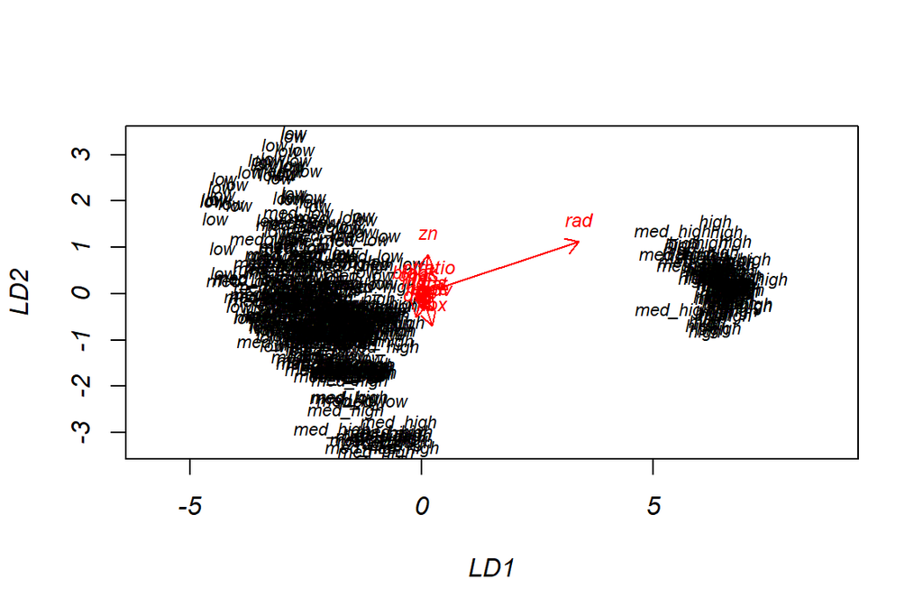

```r
# the function for lda biplot arrows
lda.arrows <- function(x, myscale = 1, arrow_heads = 0.1, color = "red", tex = 0.75, choices = c(1,2)){
  heads <- coef(x)
  graphics::arrows(x0 = 0, y0 = 0,
         x1 = myscale * heads[,choices[1]],
         y1 = myscale * heads[,choices[2]], col=color, length = arrow_heads)
  text(myscale * heads[,choices], labels = row.names(heads),
       cex = tex, col=color, pos=3)
}

# target classes as numeric
classes <- as.numeric(train$crime)

# plot the lda results (select both lines and execute them at the same time!)
plot(lda.fit, dimen = 2)
lda.arrows(lda.fit, myscale = 1)
```

- Now we can save the crime categories from the test set and predict classes with our LDA model on the test data. We previously saved the correct classes so we can use those to validate our model

```r
# predict classes with test data
lda.pred <- predict(lda.fit, newdata = test)

# cross tabulate the results
table(correct = correct_classes, predicted = lda.pred$class)
```

```
##           predicted
## correct    low med_low med_high high
##   low       13       9        0    0
##   med_low    4      22        2    0
##   med_high   0       5       21    1
##   high       0       0        1   24
```

```r
data("Boston")
boston_scaled <- as.data.frame(scale(Boston))

#distance calculations
# euclidean distance matrix
dist_eu <- dist(boston_scaled)

# look at the summary of the distances
summary(dist_eu)
```

```
##    Min. 1st Qu.  Median    Mean 3rd Qu.    Max.
##  0.1343  3.4625  4.8241  4.9111  6.1863 14.3970
```

```r
# manhattan distance matrix
dist_man <- dist(boston_scaled,method = "manhattan")

# look at the summary of the distances
summary(dist_man)
```

```
##    Min. 1st Qu.  Median    Mean 3rd Qu.    Max.
##  0.2662  8.4832 12.6090 13.5488 17.7568 48.8618
```

-Euclidean distance seems to generally be shorter in this data since it is just a straight line between data points.

- now we can run K-means using our data

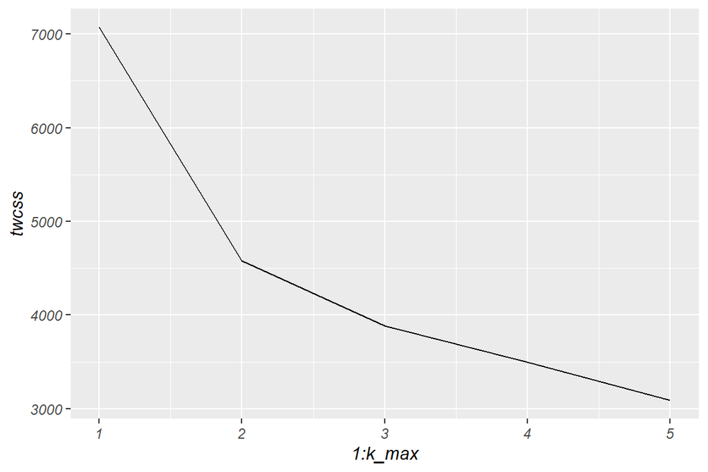

```r
set.seed(6)

# determine the number of clusters
k_max <- 5

# calculate the total within sum of squares
twcss <- sapply(1:k_max, function(k){kmeans(boston_scaled, k)$tot.withinss})

# visualize the results
qplot(x = 1:k_max, y = twcss, geom = 'line')
```

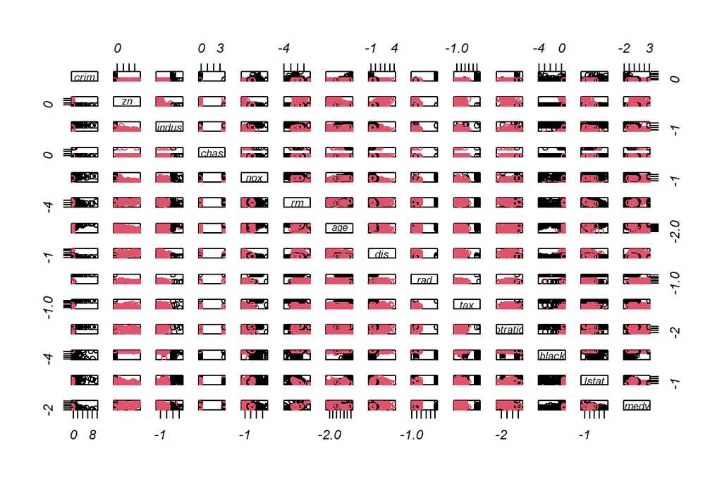

```r
# k-means clustering
km <- kmeans(boston_scaled, centers = 2)

# plot the Boston dataset with clusters
pairs(boston_scaled, col = km$cluster)
```

- Based on our twcss we can say that the optimal number of clusters is 2 as that is where the value starts dropping drastically, but 3 could also be a valid option to test.

as for the pairs analysis now we see which of the 2 clusters our data labels itself into and we can see that there are a lot of data where one cluster is overrepresented showing that the data lines up with it more.

```r
date()
```

```
## [1] "Tue Dec 12 01:21:06 2023"
```

# Chapter 5 Dimensionality reduction

- In this chapter we are working with the human dataset from https://raw.githubusercontent.com/KimmoVehkalahti/Helsinki-Open-Data-Science/master/datasets/human2.csv”
- This dataset consists of certain welfare parameters of countries ranked, these include Maternal mortality rate education rate and gender equality parameters.

“GNI” = Gross National Income per capita.

“Life.Exp” = Life expectancy at birth

“Edu.Exp” = Expected years of schooling

“Mat.Mor” = Maternal mortality ratio

“Ado.Birth” = Adolescent birth rate

“Parli.F” = Percetange of female representatives in parliament

“Edu2.FM” = Proportion of females with at least secondary education divided by males “Labo.FM” = Proportion of females in the labour force divided by males

```r
human <-read.csv("C:/Users/Kalka/OneDrive/Desktop/Random/School/Open_Data/IODS-project/data/human.csv")

# moving country names to rownames to a new dataframe human_
library(dplyr)
library(readr)
library(tibble)
library(GGally)
human_ <- column_to_rownames(human, "Country")
summary(human_)
```

```
##     Edu2.FM          Labo.FM          Edu.Exp         Life.Exp
##  Min.   :0.1717   Min.   :0.1857   Min.   : 5.40   Min.   :49.00
##  1st Qu.:0.7264   1st Qu.:0.5984   1st Qu.:11.25   1st Qu.:66.30
##  Median :0.9375   Median :0.7535   Median :13.50   Median :74.20
##  Mean   :0.8529   Mean   :0.7074   Mean   :13.18   Mean   :71.65
##  3rd Qu.:0.9968   3rd Qu.:0.8535   3rd Qu.:15.20   3rd Qu.:77.25
##  Max.   :1.4967   Max.   :1.0380   Max.   :20.20   Max.   :83.50
##       GNI            Mat.Mor         Ado.Birth         Parli.F
##  Min.   :   581   Min.   :   1.0   Min.   :  0.60   Min.   : 0.00
##  1st Qu.:  4198   1st Qu.:  11.5   1st Qu.: 12.65   1st Qu.:12.40
##  Median : 12040   Median :  49.0   Median : 33.60   Median :19.30
##  Mean   : 17628   Mean   : 149.1   Mean   : 47.16   Mean   :20.91
##  3rd Qu.: 24512   3rd Qu.: 190.0   3rd Qu.: 71.95   3rd Qu.:27.95
##  Max.   :123124   Max.   :1100.0   Max.   :204.80   Max.   :57.50
```

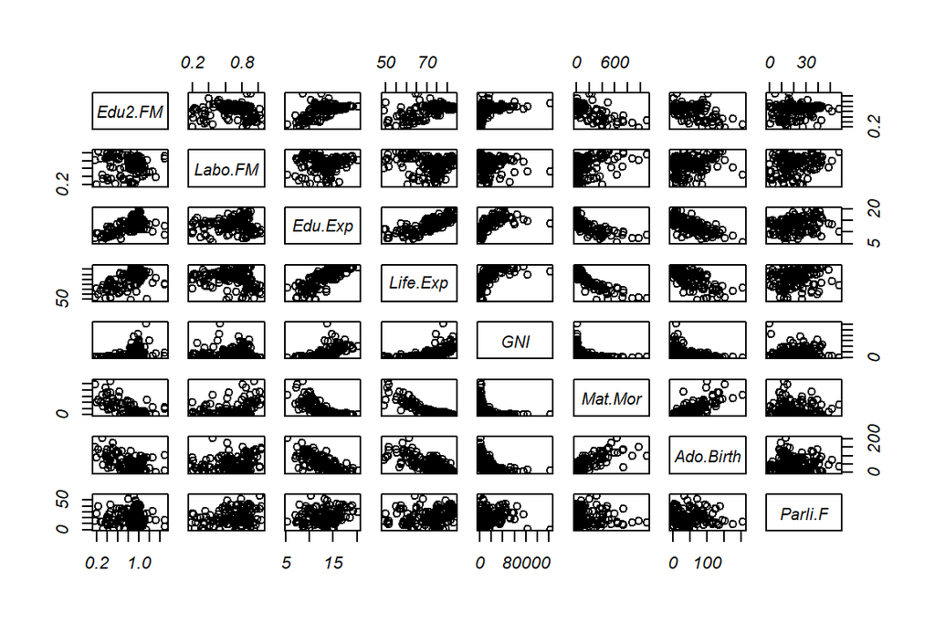

```r
pairs(human_)
```

- From these plots you can see some skewing in data especially with GNI and the variables such as Ado.Birth which would seem to indicate that Adolescent birth is more common in countries with low GNI.
- This data could use some PCA

#### PCA

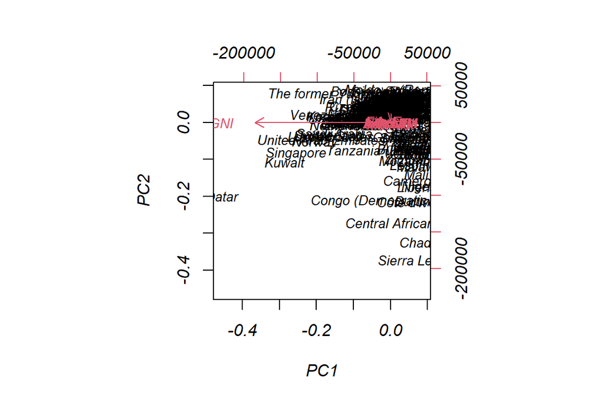

```r
# perform principal component analysis
pca_human <- prcomp(human_)

# draw a biplot of the principal component representation and the original variables
biplot(pca_human, choices = 1:2,cex=0.8)
```

- Based on this unscaled data it is pretty hard to see anything on a biplot and the plot would need to be tinkered with. Howere we can quite clearly see that a lot of variables plot around the same area. In this type of plots the arrows would be useful to determine certain properties of our data

- The angle between the arrows can be interpreted as the correlation between the variables.
- The angle between a variable and a PC axis can be interpreted as the correlation between the two
- The length of the arrows are proportional to the standard deviations of the variables.
- As you can see above the arrows aside from GNI are very hard to see and that would mean that there is a large standard deviation in GNI
- All of the arrows seem straight so this would not show any correlations

```r
# create and print out a summary of pca_human
s <- summary(pca_human)


# rounded percentanges of variance captured by each PC
pca_pr <- round(1*s$importance[2, ], digits = 5)
pca_pr
```

```
##    PC1    PC2    PC3    PC4    PC5    PC6    PC7    PC8
## 0.9999 0.0001 0.0000 0.0000 0.0000 0.0000 0.0000 0.0000
```

- based on the summary it seems that for this unscaled data the first principal component explains almost all of the variance.
- what if we standardize the variables

```r
#scaling the data
human_std <- scale(human_)
summary(human_std)
```

```
##     Edu2.FM           Labo.FM           Edu.Exp           Life.Exp
##  Min.   :-2.8189   Min.   :-2.6247   Min.   :-2.7378   Min.   :-2.7188
##  1st Qu.:-0.5233   1st Qu.:-0.5484   1st Qu.:-0.6782   1st Qu.:-0.6425
##  Median : 0.3503   Median : 0.2316   Median : 0.1140   Median : 0.3056
##  Mean   : 0.0000   Mean   : 0.0000   Mean   : 0.0000   Mean   : 0.0000
##  3rd Qu.: 0.5958   3rd Qu.: 0.7350   3rd Qu.: 0.7126   3rd Qu.: 0.6717
##  Max.   : 2.6646   Max.   : 1.6632   Max.   : 2.4730   Max.   : 1.4218
##       GNI             Mat.Mor          Ado.Birth          Parli.F
##  Min.   :-0.9193   Min.   :-0.6992   Min.   :-1.1325   Min.   :-1.8203
##  1st Qu.:-0.7243   1st Qu.:-0.6496   1st Qu.:-0.8394   1st Qu.:-0.7409
##  Median :-0.3013   Median :-0.4726   Median :-0.3298   Median :-0.1403
##  Mean   : 0.0000   Mean   : 0.0000   Mean   : 0.0000   Mean   : 0.0000
##  3rd Qu.: 0.3712   3rd Qu.: 0.1932   3rd Qu.: 0.6030   3rd Qu.: 0.6127
##  Max.   : 5.6890   Max.   : 4.4899   Max.   : 3.8344   Max.   : 3.1850
```

- basic scaling by using means. Now lets use the scaled data on the same analysis as before

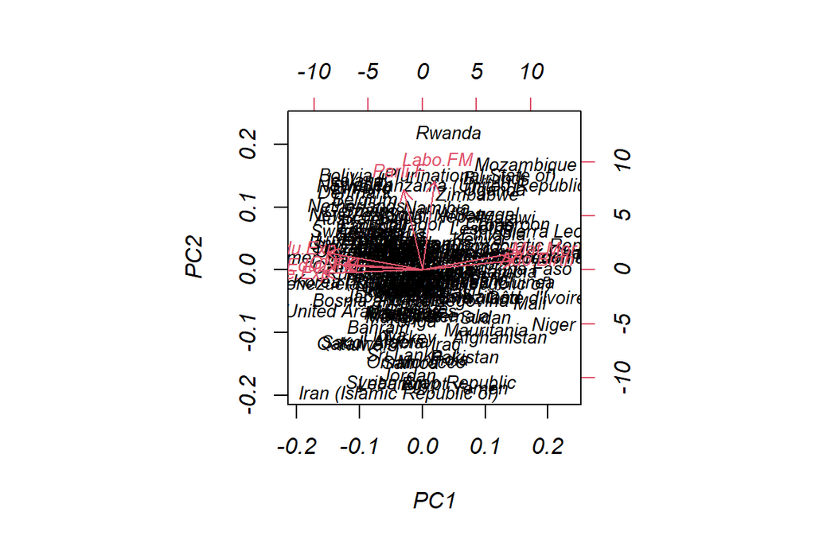

```r
# perform principal component analysis
pca_human_std <- prcomp(human_std)

# draw a biplot of the principal component representation and the original variables
biplot(pca_human_std, choices = 1:2,cex=0.8)
```

```r
# create and print out a summary of pca_human
s <- summary(pca_human_std)


# rounded percentanges of variance captured by each PC
pca_pr_std <- round(1*s$importance[2, ], digits = 5)
pca_pr_std
```

```
##     PC1     PC2     PC3     PC4     PC5     PC6     PC7     PC8
## 0.53605 0.16237 0.09571 0.07583 0.05477 0.03595 0.02634 0.01298
```

On the scaled data we can actually see that the first PC now only explains around 53% of variability and the next around 16%. For dimensionality reduction it seems valid to keep atleast the first two PC:s in this situation to represent the data in a low dimension space. I believe the scaled data would provide more intepretable data compared to the first raw data.

### Tea data

- now lets work with tea dataset from the FactoMineR package where individuals were asked about how they drink tea

```r
library(FactoMineR)
tea <- read.csv("https://raw.githubusercontent.com/KimmoVehkalahti/Helsinki-Open-Data-Science/master/datasets/tea.csv", stringsAsFactors = TRUE)
dim(tea)
```

```
## [1] 300  36
```

```r
str(tea)
```

```
## 'data.frame':    300 obs. of  36 variables:
##  $ breakfast       : Factor w/ 2 levels "breakfast","Not.breakfast": 1 1 2 2 1 2 1 2 1 1 ...
##  $ tea.time        : Factor w/ 2 levels "Not.tea time",..: 1 1 2 1 1 1 2 2 2 1 ...
##  $ evening         : Factor w/ 2 levels "evening","Not.evening": 2 2 1 2 1 2 2 1 2 1 ...
##  $ lunch           : Factor w/ 2 levels "lunch","Not.lunch": 2 2 2 2 2 2 2 2 2 2 ...
##  $ dinner          : Factor w/ 2 levels "dinner","Not.dinner": 2 2 1 1 2 1 2 2 2 2 ...
##  $ always          : Factor w/ 2 levels "always","Not.always": 2 2 2 2 1 2 2 2 2 2 ...
##  $ home            : Factor w/ 2 levels "home","Not.home": 1 1 1 1 1 1 1 1 1 1 ...
##  $ work            : Factor w/ 2 levels "Not.work","work": 1 1 2 1 1 1 1 1 1 1 ...
##  $ tearoom         : Factor w/ 2 levels "Not.tearoom",..: 1 1 1 1 1 1 1 1 1 2 ...
##  $ friends         : Factor w/ 2 levels "friends","Not.friends": 2 2 1 2 2 2 1 2 2 2 ...
##  $ resto           : Factor w/ 2 levels "Not.resto","resto": 1 1 2 1 1 1 1 1 1 1 ...
##  $ pub             : Factor w/ 2 levels "Not.pub","pub": 1 1 1 1 1 1 1 1 1 1 ...
##  $ Tea             : Factor w/ 3 levels "black","Earl Grey",..: 1 1 2 2 2 2 2 1 2 1 ...
##  $ How             : Factor w/ 4 levels "alone","lemon",..: 1 3 1 1 1 1 1 3 3 1 ...
```

[output cut: 22 more lines]

```r
view(tea)
```

- Lets choose some columns to test with MCA, for example in this I’d like to test the following (frequency,SPC,Age_Q,how ) to see if perhaps we can see anythign when looking at how much tea the individuals drank what is their social standing and age and how they made their tea

```r
library(dplyr)
# select the 'keep_columns' to create a new dataset
tea_test <- tea[, c("age_Q", "frequency", "how", "SPC")]
```

- Lets perform a MCA on the data

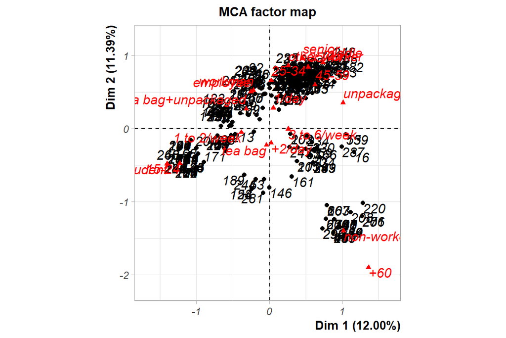

```r
mca <- MCA(tea_test, graph = FALSE)
plot.MCA(mca)
```

- This data is also a bit messy to look at due to all the observations. When looking at a MCA plot we would like to look at a multitude of different things. For example we see some clustering around certain categories which makes sence since the closer an observation is to a category means that it better represents the observation. In this case these clusters seem to happen around the social status of the people. - Another observation that could be made is that the way of drinking tea from a tea bag ( typically a fast and convenient method) seems to be close to the higher tea consumption/week categories. Though it is important to keep in mind that the distance to orgigin is also a factor and categories close to origin might not be well represented by MCA

```r
p <- summary(mca)
```

```
##
## Call:
## MCA(X = tea_test, graph = FALSE)
##
##
## Eigenvalues
##                        Dim.1   Dim.2   Dim.3   Dim.4   Dim.5   Dim.6   Dim.7
## Variance               0.450   0.427   0.318   0.307   0.283   0.279   0.269
## % of var.             12.004  11.387   8.473   8.174   7.559   7.446   7.161
## Cumulative % of var.  12.004  23.392  31.864  40.039  47.598  55.044  62.205
##                        Dim.8   Dim.9  Dim.10  Dim.11  Dim.12  Dim.13  Dim.14
## Variance               0.255   0.236   0.221   0.207   0.172   0.168   0.087
## % of var.              6.788   6.298   5.907   5.514   4.593   4.484   2.317
## Cumulative % of var.  68.992  75.290  81.197  86.711  91.304  95.788  98.105
##                       Dim.15
## Variance               0.071
## % of var.              1.895
## Cumulative % of var. 100.000
##
## Individuals (the 10 first)
##                Dim.1    ctr   cos2    Dim.2    ctr   cos2    Dim.3    ctr
## 1           |  0.480  0.171  0.058 |  0.694  0.376  0.121 |  0.365  0.139
## 2           |  0.514  0.196  0.079 |  0.600  0.281  0.108 |  0.126  0.017
## 3           |  0.324  0.078  0.021 |  0.400  0.125  0.032 |  0.625  0.410
## 4           | -0.976  0.705  0.450 | -0.343  0.092  0.056 |  0.352  0.130
## 5           |  0.132  0.013  0.007 |  0.263  0.054  0.027 | -0.089  0.008
## 6           | -0.976  0.705  0.450 | -0.343  0.092  0.056 |  0.352  0.130
## 7           |  0.453  0.152  0.036 |  0.604  0.285  0.064 | -0.343  0.123
## 8           |  0.316  0.074  0.020 |  0.566  0.250  0.065 |  0.103  0.011
## 9           |  0.260  0.050  0.015 |  0.720  0.405  0.118 | -0.567  0.338
## 10          |  0.260  0.050  0.015 |  0.720  0.405  0.118 | -0.567  0.338
##               cos2
## 1            0.033 |
## 2            0.005 |
## 3            0.078 |
## 4            0.058 |
## 5            0.003 |
## 6            0.058 |
## 7            0.021 |
## 8            0.002 |
```

[output cut: 18 more lines]

```
## 25-34       |   0.359   2.336   0.039   3.396 |
## 35-44       |   0.173   0.315   0.005   1.176 |
## 45-59       |  -0.365   2.135   0.034  -3.191 |
## +2/day      |  -0.459   7.024   0.155  -6.803 |
## 1 to 2/week |   0.246   0.696   0.010   1.760 |
## 1/day       |   0.835  17.385   0.323   9.833 |
## 3 to 6/week |  -0.936   7.820   0.112  -5.789 |
## tea bag     |   0.490  10.699   0.314   9.686 |
##
## Categorical variables (eta2)
##               Dim.1 Dim.2 Dim.3
## age_Q       | 0.816 0.798 0.072 |
## frequency   | 0.031 0.043 0.418 |
## how         | 0.155 0.067 0.338 |
## SPC         | 0.798 0.801 0.442 |
```

- Looking at the eigenvalues of MCA we see that there are no good dimensions for this MCA to explain variances with the highest being dim 1 with 12%.
- So these columns that I chose quickly seem to not be suitable together for an MCA analysis.

# Chapter 6: Analysis of longitudinal data

```r
# Data used is based on the data of Kimmo Vehkalahti from the following URL
#https://raw.githubusercontent.com/KimmoVehkalahti/MABS/master/Examples/data/BPRS.txt
#https://raw.githubusercontent.com/KimmoVehkalahti/MABS/master/Examples/data/rats.txt

ratsl <-read.csv("C:/Users/Kalka/OneDrive/Desktop/Random/School/Open_Data/IODS-project/data/ratsl.csv")
```

```r
# Loading in the data might lose categorical variables set as factors  so lets put them again

ratsl$ID<- as.factor(ratsl$ID)
ratsl$Group<-as.factor(ratsl$Group)
head(ratsl)
```

```
##   ID Group Weight Time
## 1  1     1    240    1
## 2  2     1    225    1
## 3  3     1    245    1
## 4  4     1    260    1
## 5  5     1    255    1
## 6  6     1    260    1
```

- lets follow the course book chapter 8 analysis but use the rat dataset instead of BPRSL
- The rat dataset describes the weight of 16 rats over 9 weeks of observation, The rats were assigned different diets out of 3 options. Weight is the weight of a rat in grams and time is in days

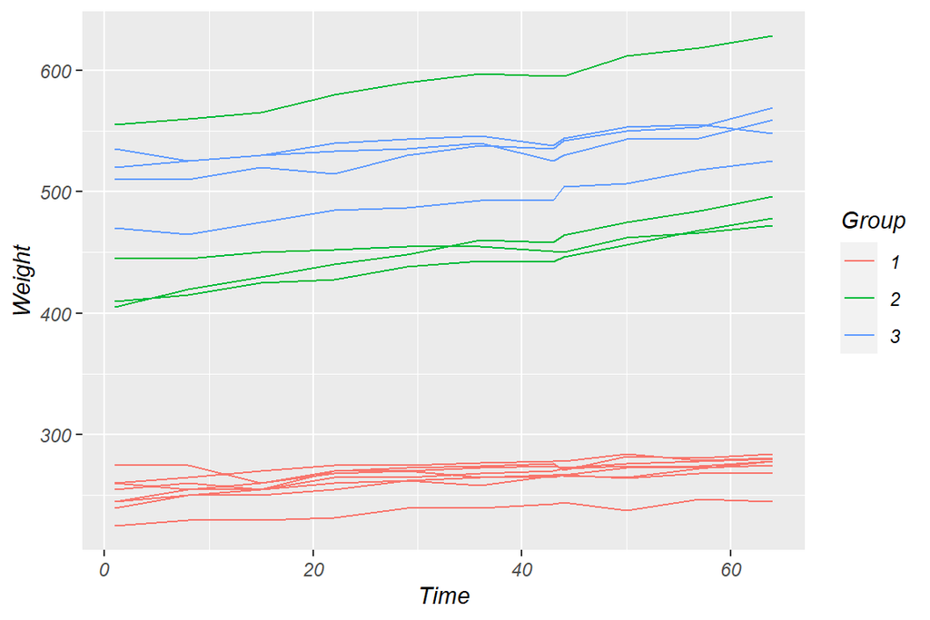

```r
# Initialising some packages that might be needed
library(ggplot2)
library(readr)
library(dplyr)
library(tidyr)
# Draw the plots
ggplot(ratsl)+geom_line(aes(x=Time,y=Weight,group=ID,color=Group))
```

- a slight increase in weight can be seen in the groups, vut initial weight is much lower in group 1. Largest weight gain seems to be in group 2

- lets do a standardization and see if it changes anything in our graph

```r
# based on Ex6 code
ratsl_std <- ratsl %>%
  group_by(Group) %>%
  mutate(stdweight = (Weight - mean(Weight))/sd(Weight)) %>%
  ungroup()

# Glimpse the data
glimpse(ratsl_std)
```

```
## Rows: 176
## Columns: 5
## $ ID        <fct> 1, 2, 3, 4, 5, 6, 7, 8, 9, 10, 11, 12, 13, 14, 15, 16, 1, 2,…
## $ Group     <fct> 1, 1, 1, 1, 1, 1, 1, 1, 2, 2, 2, 2, 3, 3, 3, 3, 1, 1, 1, 1, …
## $ Weight    <int> 240, 225, 245, 260, 255, 260, 275, 245, 410, 405, 445, 555, …
## $ Time      <int> 1, 1, 1, 1, 1, 1, 1, 1, 1, 1, 1, 1, 1, 1, 1, 1, 15, 15, 15, …
## $ stdweight <dbl> -1.7326345, -2.8285030, -1.3673450, -0.2714765, -0.6367660, …
```

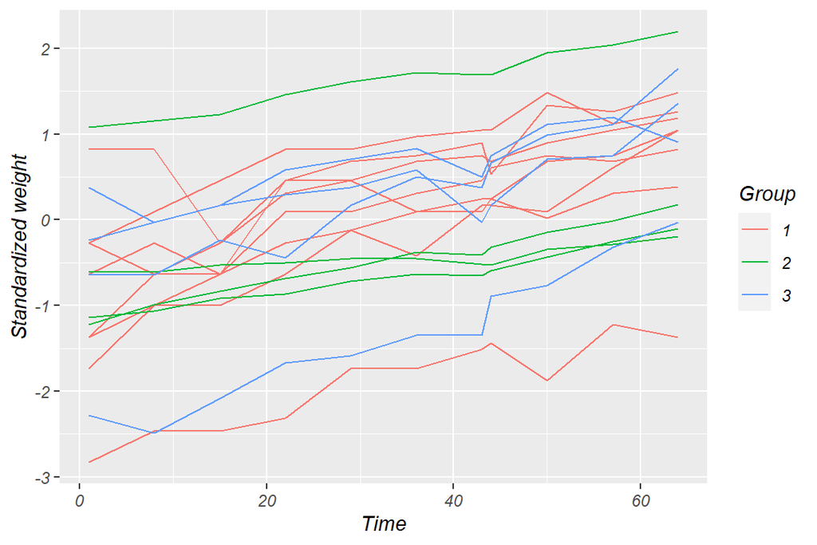

```r
# Plot again with the new data
ggplot(ratsl_std)+geom_line(aes(x=Time,y=stdweight,group=ID,color=Group))+
  labs(y = "Standardized weight")
```

- Now we can see the pattern of weight growth better which was hard to see previously due to high variation of starting weight.

- Lets plot

```r
# Summary data with mean and standard error of ratsl by treatment and week
# Function from the ex 6
se <- function(x,n) { sd(x)/sqrt(n) }

ratsl_s <- ratsl %>%
  group_by(Group, Time) %>%
  summarise(mean = mean(Weight), se = se(Weight, length(Weight)) ) %>%
  ungroup()
glimpse(ratsl_s)
```

```
## Rows: 33
## Columns: 4
## $ Group <fct> 1, 1, 1, 1, 1, 1, 1, 1, 1, 1, 1, 2, 2, 2, 2, 2, 2, 2, 2, 2, 2, 2…
## $ Time  <int> 1, 8, 15, 22, 29, 36, 43, 44, 50, 57, 64, 1, 8, 15, 22, 29, 36, …
## $ mean  <dbl> 250.625, 255.000, 254.375, 261.875, 264.625, 265.000, 267.375, 2…
## $ se    <dbl> 5.381640, 4.629100, 4.057346, 4.808614, 3.909409, 4.166190, 3.87…
```

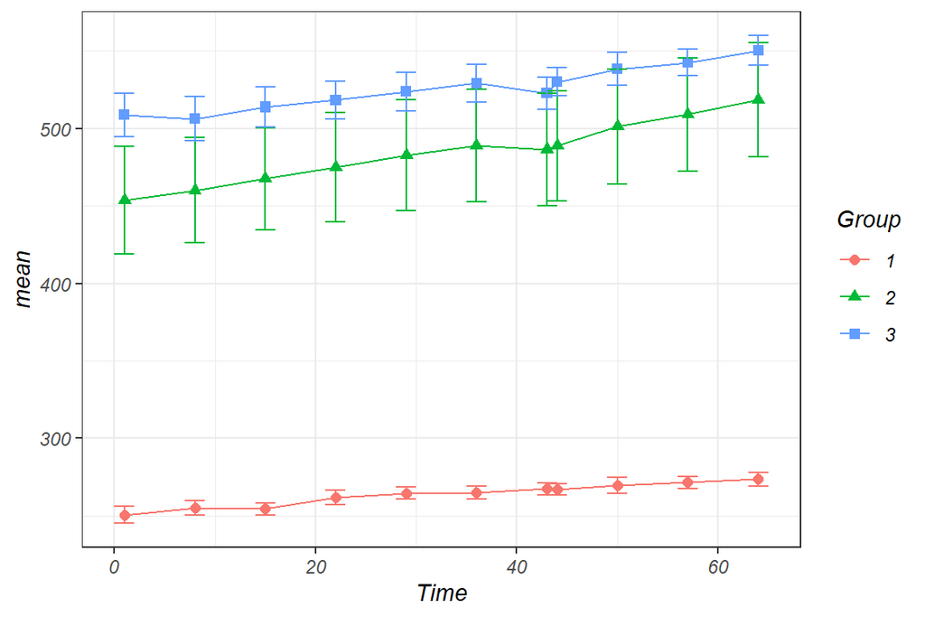

```r
ggplot(ratsl_s, aes(x = Time, y = mean, color = Group)) +
  geom_line() +
  geom_point(aes(shape=Group), size=2) +
  theme_bw() +
  geom_errorbar(aes(ymin = mean-se, ymax = mean+se), width=2)
```

- Variation in group 1 is smaller than the others especially group 2 has a large variation which might be due to an outlier group.

- lets do a boxplot to see any potential outliers

```r
ratsl_bp <- ratsl %>%
  group_by(Group, ID) %>%
  summarise(mean=mean(Weight) ) %>%
  ungroup()
```

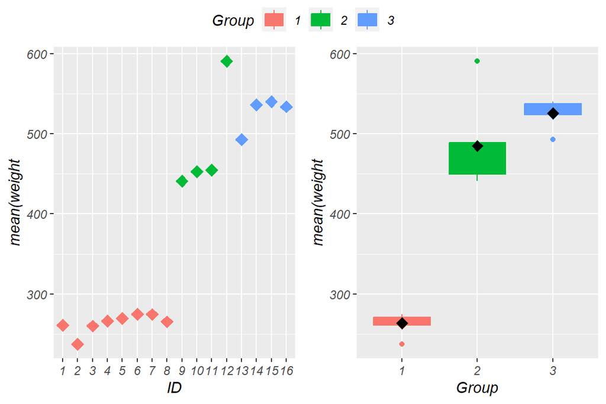

```r
library(ggplot2)
library(ggpubr)
box1 <-ggplot(ratsl_bp, aes(x = ID, y = mean,color=Group,fill=Group)) +
  geom_boxplot() +
  stat_summary(fun = "mean", geom = "point", shape=23, size=3) +
  scale_y_continuous(name = "mean(weight")

box2 <-ggplot(ratsl_bp, aes(x = Group, y = mean, color=Group,fill=Group)) +
  geom_boxplot() +
  stat_summary(fun = "mean", geom = "point", shape=23, size=3,fill="black") +
  scale_y_continuous(name = "mean(weight")

ggarrange(box1,box2, common.legend=T)
```

- Based on this one could say that rats 2 12 and 13 are outliers when compared to their groups.

- Filtering the outliers and trying again

```r
ratsl_fltr <- ratsl %>%
  filter(ID != 2 & ID != 12 & ID != 13) %>%
  group_by(Group, ID) %>%
  summarise(mean=mean(Weight) ) %>%
  ungroup()
```

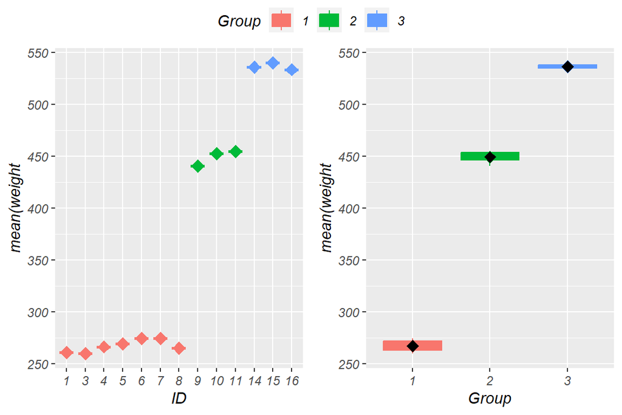

```r
library(ggplot2)
library(ggpubr)
box1 <-ggplot(ratsl_fltr, aes(x = ID, y = mean,color=Group,fill=Group)) +
  geom_boxplot() +
  stat_summary(fun = "mean", geom = "point", shape=23, size=3) +
  scale_y_continuous(name = "mean(weight")

box2 <-ggplot(ratsl_fltr, aes(x = Group, y = mean, color=Group,fill=Group)) +
  geom_boxplot() +
  stat_summary(fun = "mean", geom = "point", shape=23, size=3,fill="black") +
  scale_y_continuous(name = "mean(weight")

ggarrange(box1,box2, common.legend=T)
```

- Data seems to be now more uniform - Lastly lets fit a linear model and analyze it

```r
# We need to filter the base data
ratsl_fltr <- ratsl %>%
  filter(ID != 2 & ID != 12 & ID != 13)

ratsl_lm <- lm(data=ratsl_fltr,Weight~Time+Group)

summary(ratsl_lm)
```

```
##
## Call:
## lm(formula = Weight ~ Time + Group, data = ratsl_fltr)
##
## Residuals:
##      Min       1Q   Median       3Q      Max
## -26.9941  -5.7803  -0.0744   5.6949  30.2068
##
## Coefficients:
##              Estimate Std. Error t value Pr(>|t|)
## (Intercept) 249.44461    1.69082  147.53   <2e-16 ***
## Time          0.53649    0.03955   13.57   <2e-16 ***
## Group2      182.01299    1.91405   95.09   <2e-16 ***
## Group3      269.31602    1.91405  140.71   <2e-16 ***
## ---
## Signif. codes:  0 '***' 0.001 '**' 0.01 '*' 0.05 '.' 0.1 ' ' 1
##
## Residual standard error: 9.199 on 139 degrees of freedom
## Multiple R-squared:  0.994,  Adjusted R-squared:  0.9939
## F-statistic:  7685 on 3 and 139 DF,  p-value: < 2.2e-16
```

```r
anova(ratsl_lm)
```

```
## Analysis of Variance Table
##
## Response: Weight
##            Df  Sum Sq Mean Sq  F value    Pr(>F)
## Time        1   15576   15576   184.05 < 2.2e-16 ***
## Group       2 1935537  967769 11435.47 < 2.2e-16 ***
## Residuals 139   11763      85
## ---
## Signif. codes:  0 '***' 0.001 '**' 0.01 '*' 0.05 '.' 0.1 ' ' 1
```

- there seems to be a very low p-value on all groups so the difference is significant -R squared of 0.994 says that 99.4% of our variation can be attributed to our variables

### Chapter 6 part 2 (BPRS data analysis)

-The BPRS data consists of brief psychiatric rating scale values for 40 men before and after treatment on different time frames on two different treatment groups

```r
BPRSL <-read.csv("C:/Users/Kalka/OneDrive/Desktop/Random/School/Open_Data/IODS-project/data/BPRSL.csv")
BPRSL<- as.data.frame(BPRSL)
BPRSL$subject <- as.factor(BPRSL$subject)
BPRSL$treatment <- as.factor(BPRSL$treatment)

summary(BPRSL)
```

```
##  treatment    subject         bprs            week
##  1:180     1      : 18   Min.   :18.00   Min.   :0
##  2:180     2      : 18   1st Qu.:27.00   1st Qu.:2
##            3      : 18   Median :35.00   Median :4
##            4      : 18   Mean   :37.66   Mean   :4
##            5      : 18   3rd Qu.:43.00   3rd Qu.:6
##            6      : 18   Max.   :95.00   Max.   :8
##            (Other):252
```

```r
str(BPRSL)
```

```
## 'data.frame':    360 obs. of  4 variables:
##  $ treatment: Factor w/ 2 levels "1","2": 1 1 1 1 1 1 1 1 1 1 ...
##  $ subject  : Factor w/ 20 levels "1","2","3","4",..: 1 2 3 4 5 6 7 8 9 10 ...
##  $ bprs     : int  42 58 54 55 72 48 71 30 41 57 ...
##  $ week     : int  0 0 0 0 0 0 0 0 0 0 ...
```

- Treatment is a variable with either 1 or 2 which shows the treatment group
- subject is an identifier for the individual
- bprs is the brief psychiatric rating scale
- week is the time of data collection

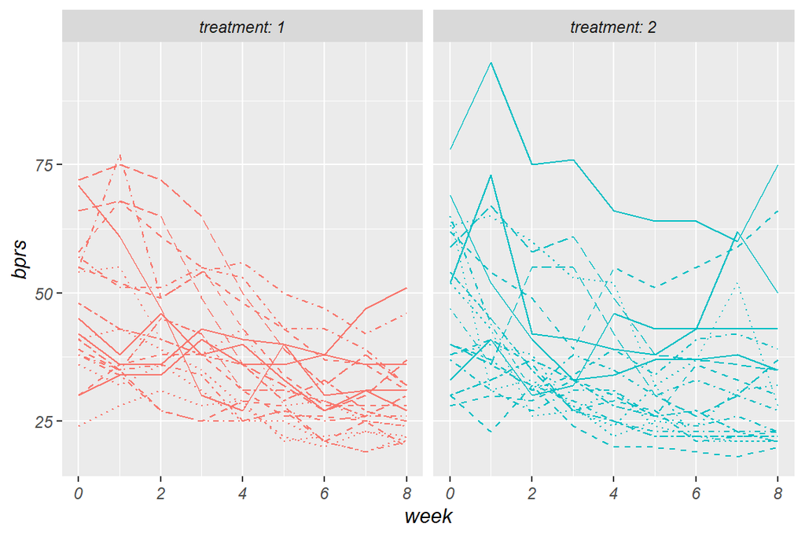

```r
ggplot(BPRSL, aes(x = week, y = bprs, linetype = subject, color=treatment)) +
  geom_line() +
  scale_linetype_manual(values = rep(1:10, times=4)) +
  facet_grid(. ~ treatment, labeller = label_both) +
  theme(legend.position = "none") +
  scale_y_continuous(limits = c(min(BPRSL$bprs), max(BPRSL$bprs)))
```

- both groups have a downwards trend although some Ids show variability

Fitting a linear model

```r
# basic linear model
BPRS_lm <- lm(bprs ~ week + treatment, data = BPRSL)
summary(BPRS_lm)
```

```
##
## Call:
## lm(formula = bprs ~ week + treatment, data = BPRSL)
##
## Residuals:
##     Min      1Q  Median      3Q     Max
## -22.454  -8.965  -3.196   7.002  50.244
##
## Coefficients:
##             Estimate Std. Error t value Pr(>|t|)
## (Intercept)  46.4539     1.3670  33.982   <2e-16 ***
## week         -2.2704     0.2524  -8.995   <2e-16 ***
## treatment2    0.5722     1.3034   0.439    0.661
## ---
## Signif. codes:  0 '***' 0.001 '**' 0.01 '*' 0.05 '.' 0.1 ' ' 1
##
## Residual standard error: 12.37 on 357 degrees of freedom
## Multiple R-squared:  0.1851, Adjusted R-squared:  0.1806
## F-statistic: 40.55 on 2 and 357 DF,  p-value: < 2.2e-16
```

- Based on this there would seem to be no difference between treatments and both treatments seem to reduce the symtoms(bprs score)
- how about other model

```r
library(lme4)
library(Matrix)
```

```r
# random intercept model

BPRS_ref <- lmer(bprs ~ week + treatment + (1 | subject), data = BPRSL, REML = FALSE)
summary(BPRS_ref)
```

```
## Linear mixed model fit by maximum likelihood  ['lmerMod']
## Formula: bprs ~ week + treatment + (1 | subject)
##    Data: BPRSL
##
##      AIC      BIC   logLik deviance df.resid
##   2748.7   2768.1  -1369.4   2738.7      355
##
## Scaled residuals:
##     Min      1Q  Median      3Q     Max
## -3.0481 -0.6749 -0.1361  0.4813  3.4855
##
## Random effects:
##  Groups   Name        Variance Std.Dev.
##  subject  (Intercept)  47.41    6.885
##  Residual             104.21   10.208
## Number of obs: 360, groups:  subject, 20
##
## Fixed effects:
##             Estimate Std. Error t value
## (Intercept)  46.4539     1.9090  24.334
## week         -2.2704     0.2084 -10.896
## treatment2    0.5722     1.0761   0.532
##
## Correlation of Fixed Effects:
##            (Intr) week
## week       -0.437
## treatment2 -0.282  0.000
```

```r
#random intercept and slope model
BPRS_ref2 <- lmer(bprs ~ week + treatment + (week | subject), data = BPRSL, REML = FALSE)
summary(BPRS_ref2)
```

```
## Linear mixed model fit by maximum likelihood  ['lmerMod']
## Formula: bprs ~ week + treatment + (week | subject)
##    Data: BPRSL
##
##      AIC      BIC   logLik deviance df.resid
##   2745.4   2772.6  -1365.7   2731.4      353
##
## Scaled residuals:
##     Min      1Q  Median      3Q     Max
## -2.8919 -0.6194 -0.0691  0.5531  3.7976
##
## Random effects:
##  Groups   Name        Variance Std.Dev. Corr
##  subject  (Intercept) 64.8222  8.0512
##           week         0.9609  0.9802   -0.51
##  Residual             97.4305  9.8707
## Number of obs: 360, groups:  subject, 20
##
## Fixed effects:
##             Estimate Std. Error t value
## (Intercept)  46.4539     2.1052  22.066
## week         -2.2704     0.2977  -7.626
## treatment2    0.5722     1.0405   0.550
##
## Correlation of Fixed Effects:
##            (Intr) week
## week       -0.582
## treatment2 -0.247  0.000
```

```r
anova(BPRS_ref, BPRS_lm)
```

```
## Data: BPRSL
## Models:
## BPRS_lm: bprs ~ week + treatment
## BPRS_ref: bprs ~ week + treatment + (1 | subject)
##          npar    AIC    BIC  logLik deviance  Chisq Df Pr(>Chisq)
## BPRS_lm     4 2837.3 2852.9 -1414.7   2829.3
## BPRS_ref    5 2748.7 2768.1 -1369.4   2738.7 90.624  1  < 2.2e-16 ***
## ---
## Signif. codes:  0 '***' 0.001 '**' 0.01 '*' 0.05 '.' 0.1 ' ' 1
```

```r
anova(BPRS_ref2,BPRS_ref)
```

```
## Data: BPRSL
## Models:
## BPRS_ref: bprs ~ week + treatment + (1 | subject)
## BPRS_ref2: bprs ~ week + treatment + (week | subject)
##           npar    AIC    BIC  logLik deviance  Chisq Df Pr(>Chisq)
## BPRS_ref     5 2748.7 2768.1 -1369.4   2738.7
## BPRS_ref2    7 2745.4 2772.6 -1365.7   2731.4 7.2721  2    0.02636 *
## ---
## Signif. codes:  0 '***' 0.001 '**' 0.01 '*' 0.05 '.' 0.1 ' ' 1
```

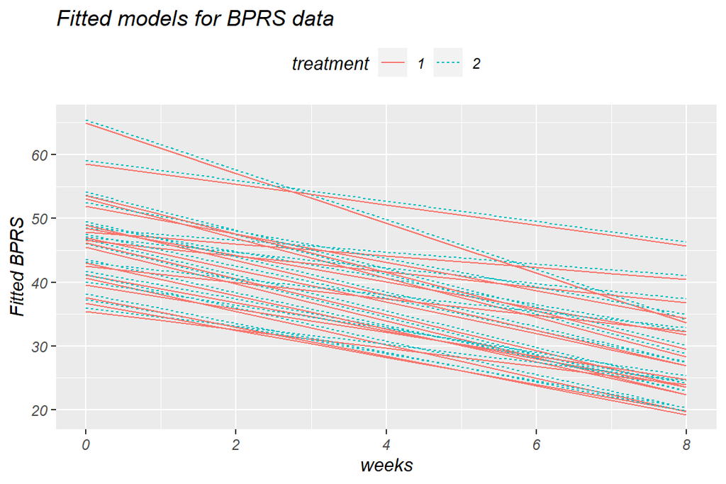

```r
#Lets plot our model
Fitted <- fitted(BPRS_ref2)
BPRSL$Fitted <- Fitted

ggplot(BPRSL, aes(x = week, y = Fitted, group = interaction(treatment, subject))) +
  geom_line(aes(linetype = treatment, colour=treatment)) +
  scale_x_continuous(name = "weeks")+
  scale_y_continuous(name = "Fitted BPRS") +
  theme(legend.position = "top")  +
  ggtitle("Fitted models for BPRS data")
```

- From this it would seem that both treatments reduce the symptoms and neither seems to be better than the other.